# Risk Factor Analysis

## Outcome Variable

**Outcome Variable:** ever_swasted

## Predictor Variables

**Intervention Variable:** sex

**Adjustment Set:**

unadjusted

## Stratifying Variables

The analysis was stratified on these variable(s):

- agecat
- studyid
- country

## Data Summary

| agecat | studyid | country | sex | ever_swasted | n_cell | n |
| --- | --- | --- | --- | --- | --- | --- |
| 0-24 months | ki0047075b-MAL-ED | BANGLADESH | Female | 0 | 121 | 263 |
| 0-24 months | ki0047075b-MAL-ED | BANGLADESH | Female | 1 | 13 | 263 |
| 0-24 months | ki0047075b-MAL-ED | BANGLADESH | Male | 0 | 121 | 263 |
| 0-24 months | ki0047075b-MAL-ED | BANGLADESH | Male | 1 | 8 | 263 |
| 0-24 months | ki0047075b-MAL-ED | BRAZIL | Female | 0 | 112 | 233 |
| 0-24 months | ki0047075b-MAL-ED | BRAZIL | Female | 1 | 1 | 233 |
| 0-24 months | ki0047075b-MAL-ED | BRAZIL | Male | 0 | 117 | 233 |
| 0-24 months | ki0047075b-MAL-ED | BRAZIL | Male | 1 | 3 | 233 |
| 0-24 months | ki0047075b-MAL-ED | INDIA | Female | 0 | 125 | 251 |
| 0-24 months | ki0047075b-MAL-ED | INDIA | Female | 1 | 13 | 251 |
| 0-24 months | ki0047075b-MAL-ED | INDIA | Male | 0 | 102 | 251 |
| 0-24 months | ki0047075b-MAL-ED | INDIA | Male | 1 | 11 | 251 |
| 0-24 months | ki0047075b-MAL-ED | NEPAL | Female | 0 | 107 | 240 |
| 0-24 months | ki0047075b-MAL-ED | NEPAL | Female | 1 | 3 | 240 |
| 0-24 months | ki0047075b-MAL-ED | NEPAL | Male | 0 | 124 | 240 |
| 0-24 months | ki0047075b-MAL-ED | NEPAL | Male | 1 | 6 | 240 |
| 0-24 months | ki0047075b-MAL-ED | PERU | Female | 0 | 141 | 302 |
| 0-24 months | ki0047075b-MAL-ED | PERU | Female | 1 | 1 | 302 |
| 0-24 months | ki0047075b-MAL-ED | PERU | Male | 0 | 158 | 302 |
| 0-24 months | ki0047075b-MAL-ED | PERU | Male | 1 | 2 | 302 |
| 0-24 months | ki0047075b-MAL-ED | SOUTH AFRICA | Female | 0 | 154 | 312 |
| 0-24 months | ki0047075b-MAL-ED | SOUTH AFRICA | Female | 1 | 4 | 312 |
| 0-24 months | ki0047075b-MAL-ED | SOUTH AFRICA | Male | 0 | 144 | 312 |
| 0-24 months | ki0047075b-MAL-ED | SOUTH AFRICA | Male | 1 | 10 | 312 |
| 0-24 months | ki0047075b-MAL-ED | TANZANIA, UNITED REPUBLIC OF | Female | 0 | 130 | 261 |
| 0-24 months | ki0047075b-MAL-ED | TANZANIA, UNITED REPUBLIC OF | Female | 1 | 2 | 261 |
| 0-24 months | ki0047075b-MAL-ED | TANZANIA, UNITED REPUBLIC OF | Male | 0 | 124 | 261 |
| 0-24 months | ki0047075b-MAL-ED | TANZANIA, UNITED REPUBLIC OF | Male | 1 | 5 | 261 |
| 0-24 months | ki1000108-CMC-V-BCS-2002 | INDIA | Female | 0 | 141 | 373 |
| 0-24 months | ki1000108-CMC-V-BCS-2002 | INDIA | Female | 1 | 46 | 373 |

[output cut: 374 more lines]

The following strata were considered:

- agecat: 0-24 months, studyid: ki0047075b-MAL-ED, country: BANGLADESH
- agecat: 0-24 months, studyid: ki0047075b-MAL-ED, country: BRAZIL
- agecat: 0-24 months, studyid: ki0047075b-MAL-ED, country: INDIA
- agecat: 0-24 months, studyid: ki0047075b-MAL-ED, country: NEPAL
- agecat: 0-24 months, studyid: ki0047075b-MAL-ED, country: PERU
- agecat: 0-24 months, studyid: ki0047075b-MAL-ED, country: SOUTH AFRICA
- agecat: 0-24 months, studyid: ki0047075b-MAL-ED, country: TANZANIA, UNITED REPUBLIC OF
- agecat: 0-24 months, studyid: ki1000108-CMC-V-BCS-2002, country: INDIA
- agecat: 0-24 months, studyid: ki1000108-IRC, country: INDIA
- agecat: 0-24 months, studyid: ki1000109-EE, country: PAKISTAN
- agecat: 0-24 months, studyid: ki1000109-ResPak, country: PAKISTAN
- agecat: 0-24 months, studyid: ki1000304b-SAS-CompFeed, country: INDIA
- agecat: 0-24 months, studyid: ki1000304b-SAS-FoodSuppl, country: INDIA
- agecat: 0-24 months, studyid: ki1017093-NIH-Birth, country: BANGLADESH
- agecat: 0-24 months, studyid: ki1017093b-PROVIDE, country: BANGLADESH
- agecat: 0-24 months, studyid: ki1017093c-NIH-Crypto, country: BANGLADESH
- agecat: 0-24 months, studyid: ki1066203-TanzaniaChild2, country: TANZANIA, UNITED REPUBLIC OF
- agecat: 0-24 months, studyid: ki1101329-Keneba, country: GAMBIA
- agecat: 0-24 months, studyid: ki1112895-Guatemala BSC, country: GUATEMALA
- agecat: 0-24 months, studyid: ki1112895-iLiNS-Zinc, country: BURKINA FASO
- agecat: 0-24 months, studyid: ki1113344-GMS-Nepal, country: NEPAL
- agecat: 0-24 months, studyid: ki1114097-CMIN, country: BANGLADESH
- agecat: 0-24 months, studyid: ki1114097-CMIN, country: BRAZIL
- agecat: 0-24 months, studyid: ki1114097-CMIN, country: GUINEA-BISSAU
- agecat: 0-24 months, studyid: ki1114097-CMIN, country: PERU
- agecat: 0-24 months, studyid: ki1114097-CONTENT, country: PERU
- agecat: 0-24 months, studyid: ki1119695-PROBIT, country: BELARUS
- agecat: 0-24 months, studyid: ki1126311-ZVITAMBO, country: ZIMBABWE
- agecat: 0-24 months, studyid: ki1135781-COHORTS, country: GUATEMALA
- agecat: 0-24 months, studyid: ki1135781-COHORTS, country: INDIA
- agecat: 0-24 months, studyid: ki1135781-COHORTS, country: PHILIPPINES
- agecat: 0-24 months, studyid: ki1148112-LCNI-5, country: MALAWI
- agecat: 0-24 months, studyid: kiGH5241-JiVitA-3, country: BANGLADESH
- agecat: 0-24 months, studyid: kiGH5241-JiVitA-4, country: BANGLADESH
- agecat: 0-6 months, studyid: ki0047075b-MAL-ED, country: BANGLADESH
- agecat: 0-6 months, studyid: ki0047075b-MAL-ED, country: BRAZIL
- agecat: 0-6 months, studyid: ki0047075b-MAL-ED, country: INDIA
- agecat: 0-6 months, studyid: ki0047075b-MAL-ED, country: NEPAL
- agecat: 0-6 months, studyid: ki0047075b-MAL-ED, country: PERU
- agecat: 0-6 months, studyid: ki0047075b-MAL-ED, country: SOUTH AFRICA
- agecat: 0-6 months, studyid: ki0047075b-MAL-ED, country: TANZANIA, UNITED REPUBLIC OF
- agecat: 0-6 months, studyid: ki1000108-CMC-V-BCS-2002, country: INDIA
- agecat: 0-6 months, studyid: ki1000108-IRC, country: INDIA
- agecat: 0-6 months, studyid: ki1000109-EE, country: PAKISTAN
- agecat: 0-6 months, studyid: ki1000109-ResPak, country: PAKISTAN
- agecat: 0-6 months, studyid: ki1000304b-SAS-CompFeed, country: INDIA
- agecat: 0-6 months, studyid: ki1000304b-SAS-FoodSuppl, country: INDIA
- agecat: 0-6 months, studyid: ki1017093-NIH-Birth, country: BANGLADESH
- agecat: 0-6 months, studyid: ki1017093b-PROVIDE, country: BANGLADESH
- agecat: 0-6 months, studyid: ki1017093c-NIH-Crypto, country: BANGLADESH
- agecat: 0-6 months, studyid: ki1066203-TanzaniaChild2, country: TANZANIA, UNITED REPUBLIC OF
- agecat: 0-6 months, studyid: ki1101329-Keneba, country: GAMBIA
- agecat: 0-6 months, studyid: ki1112895-Guatemala BSC, country: GUATEMALA
- agecat: 0-6 months, studyid: ki1113344-GMS-Nepal, country: NEPAL
- agecat: 0-6 months, studyid: ki1114097-CMIN, country: BANGLADESH
- agecat: 0-6 months, studyid: ki1114097-CMIN, country: BRAZIL
- agecat: 0-6 months, studyid: ki1114097-CMIN, country: GUINEA-BISSAU
- agecat: 0-6 months, studyid: ki1114097-CMIN, country: PERU
- agecat: 0-6 months, studyid: ki1114097-CONTENT, country: PERU
- agecat: 0-6 months, studyid: ki1119695-PROBIT, country: BELARUS
- agecat: 0-6 months, studyid: ki1126311-ZVITAMBO, country: ZIMBABWE
- agecat: 0-6 months, studyid: ki1135781-COHORTS, country: GUATEMALA
- agecat: 0-6 months, studyid: ki1135781-COHORTS, country: INDIA
- agecat: 0-6 months, studyid: ki1135781-COHORTS, country: PHILIPPINES
- agecat: 0-6 months, studyid: ki1148112-LCNI-5, country: MALAWI
- agecat: 0-6 months, studyid: kiGH5241-JiVitA-3, country: BANGLADESH
- agecat: 0-6 months, studyid: kiGH5241-JiVitA-4, country: BANGLADESH
- agecat: 6-24 months, studyid: ki0047075b-MAL-ED, country: BANGLADESH
- agecat: 6-24 months, studyid: ki0047075b-MAL-ED, country: BRAZIL
- agecat: 6-24 months, studyid: ki0047075b-MAL-ED, country: INDIA
- agecat: 6-24 months, studyid: ki0047075b-MAL-ED, country: NEPAL
- agecat: 6-24 months, studyid: ki0047075b-MAL-ED, country: PERU
- agecat: 6-24 months, studyid: ki0047075b-MAL-ED, country: SOUTH AFRICA
- agecat: 6-24 months, studyid: ki0047075b-MAL-ED, country: TANZANIA, UNITED REPUBLIC OF
- agecat: 6-24 months, studyid: ki1000108-CMC-V-BCS-2002, country: INDIA
- agecat: 6-24 months, studyid: ki1000108-IRC, country: INDIA
- agecat: 6-24 months, studyid: ki1000109-EE, country: PAKISTAN
- agecat: 6-24 months, studyid: ki1000109-ResPak, country: PAKISTAN
- agecat: 6-24 months, studyid: ki1000304b-SAS-CompFeed, country: INDIA
- agecat: 6-24 months, studyid: ki1000304b-SAS-FoodSuppl, country: INDIA
- agecat: 6-24 months, studyid: ki1017093-NIH-Birth, country: BANGLADESH
- agecat: 6-24 months, studyid: ki1017093b-PROVIDE, country: BANGLADESH
- agecat: 6-24 months, studyid: ki1017093c-NIH-Crypto, country: BANGLADESH
- agecat: 6-24 months, studyid: ki1066203-TanzaniaChild2, country: TANZANIA, UNITED REPUBLIC OF
- agecat: 6-24 months, studyid: ki1101329-Keneba, country: GAMBIA
- agecat: 6-24 months, studyid: ki1112895-Guatemala BSC, country: GUATEMALA
- agecat: 6-24 months, studyid: ki1112895-iLiNS-Zinc, country: BURKINA FASO
- agecat: 6-24 months, studyid: ki1113344-GMS-Nepal, country: NEPAL
- agecat: 6-24 months, studyid: ki1114097-CMIN, country: BANGLADESH
- agecat: 6-24 months, studyid: ki1114097-CMIN, country: BRAZIL
- agecat: 6-24 months, studyid: ki1114097-CMIN, country: GUINEA-BISSAU
- agecat: 6-24 months, studyid: ki1114097-CMIN, country: PERU
- agecat: 6-24 months, studyid: ki1114097-CONTENT, country: PERU
- agecat: 6-24 months, studyid: ki1119695-PROBIT, country: BELARUS
- agecat: 6-24 months, studyid: ki1126311-ZVITAMBO, country: ZIMBABWE
- agecat: 6-24 months, studyid: ki1135781-COHORTS, country: GUATEMALA
- agecat: 6-24 months, studyid: ki1135781-COHORTS, country: INDIA
- agecat: 6-24 months, studyid: ki1135781-COHORTS, country: PHILIPPINES
- agecat: 6-24 months, studyid: ki1148112-LCNI-5, country: MALAWI
- agecat: 6-24 months, studyid: kiGH5241-JiVitA-3, country: BANGLADESH
- agecat: 6-24 months, studyid: kiGH5241-JiVitA-4, country: BANGLADESH

### Dropped Strata

Some strata were dropped due to rare outcomes:

- agecat: 0-24 months, studyid: ki0047075b-MAL-ED, country: BRAZIL
- agecat: 0-24 months, studyid: ki0047075b-MAL-ED, country: NEPAL
- agecat: 0-24 months, studyid: ki0047075b-MAL-ED, country: PERU
- agecat: 0-24 months, studyid: ki0047075b-MAL-ED, country: SOUTH AFRICA
- agecat: 0-24 months, studyid: ki0047075b-MAL-ED, country: TANZANIA, UNITED REPUBLIC OF
- agecat: 0-24 months, studyid: ki1112895-Guatemala BSC, country: GUATEMALA
- agecat: 0-24 months, studyid: ki1114097-CMIN, country: BRAZIL
- agecat: 0-24 months, studyid: ki1114097-CONTENT, country: PERU
- agecat: 0-24 months, studyid: ki1148112-LCNI-5, country: MALAWI
- agecat: 0-6 months, studyid: ki0047075b-MAL-ED, country: BRAZIL
- agecat: 0-6 months, studyid: ki0047075b-MAL-ED, country: NEPAL
- agecat: 0-6 months, studyid: ki0047075b-MAL-ED, country: PERU
- agecat: 0-6 months, studyid: ki0047075b-MAL-ED, country: SOUTH AFRICA
- agecat: 0-6 months, studyid: ki0047075b-MAL-ED, country: TANZANIA, UNITED REPUBLIC OF
- agecat: 0-6 months, studyid: ki1000304b-SAS-FoodSuppl, country: INDIA
- agecat: 0-6 months, studyid: ki1112895-Guatemala BSC, country: GUATEMALA
- agecat: 0-6 months, studyid: ki1114097-CMIN, country: BRAZIL
- agecat: 0-6 months, studyid: ki1114097-CONTENT, country: PERU
- agecat: 0-6 months, studyid: ki1148112-LCNI-5, country: MALAWI
- agecat: 6-24 months, studyid: ki0047075b-MAL-ED, country: BANGLADESH
- agecat: 6-24 months, studyid: ki0047075b-MAL-ED, country: BRAZIL
- agecat: 6-24 months, studyid: ki0047075b-MAL-ED, country: INDIA
- agecat: 6-24 months, studyid: ki0047075b-MAL-ED, country: NEPAL
- agecat: 6-24 months, studyid: ki0047075b-MAL-ED, country: PERU
- agecat: 6-24 months, studyid: ki0047075b-MAL-ED, country: SOUTH AFRICA
- agecat: 6-24 months, studyid: ki0047075b-MAL-ED, country: TANZANIA, UNITED REPUBLIC OF
- agecat: 6-24 months, studyid: ki1112895-Guatemala BSC, country: GUATEMALA
- agecat: 6-24 months, studyid: ki1114097-CMIN, country: BRAZIL
- agecat: 6-24 months, studyid: ki1114097-CMIN, country: PERU
- agecat: 6-24 months, studyid: ki1114097-CONTENT, country: PERU
- agecat: 6-24 months, studyid: ki1119695-PROBIT, country: BELARUS
- agecat: 6-24 months, studyid: ki1148112-LCNI-5, country: MALAWI

## Methods Detail

We’re interested in the causal parameters $E[Y_a]$ for all values of $a \in \mathcal{A}$. These parameters represent the mean outcome if, possibly contrary to fact, we intervened to set all units to have $A=a$. Under the randomization and positivity assumptions, these are identified by the statistical parameters $\psi_a=E_W[E_{Y|A,W}(Y|A=a,W)]$. In addition, we’re interested in the mean of $Y$, $E[Y]$ under no intervention (the observed mean). We will estimate these parameters by using SuperLearner to fit the relevant likelihood factors – $E_{Y|A,W}(Y|A=a,W)$ and $p(A=a|W)$, and then updating our likelihood fit using a joint TMLE.

For unadjusted analyses ($W=\{\}$), initial likelihoods were estimated using Lrnr_glm to estimate the simple $E(Y|A)$ and Lrnr_mean to estimate $p(A)$. For adjusted analyses, a small library containing Lrnr_glmnet, Lrnr_xgboost, and Lrnr_mean was used.

Having estimated these parameters, we will then use the delta method to estimate relative risks and attributable risks relative to a prespecified baseline level of $A$.

# Results Detail

## Results Plots

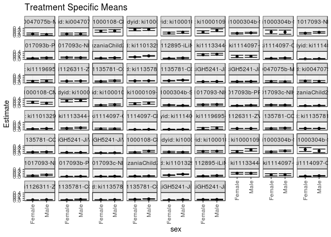

[figure not shown]

[figure not shown]

[figure not shown]

## Results Table

### Parameter: TSM

| agecat | studyid | country | intervention_level | baseline_level | estimate | ci_lower | ci_upper |
| --- | --- | --- | --- | --- | --- | --- | --- |
| 0-24 months | ki0047075b-MAL-ED | BANGLADESH | Female | NA | 0.0970149 | 0.0468058 | 0.1472240 |
| 0-24 months | ki0047075b-MAL-ED | BANGLADESH | Male | NA | 0.0620155 | 0.0203162 | 0.1037148 |
| 0-24 months | ki0047075b-MAL-ED | INDIA | Female | NA | 0.0942029 | 0.0453688 | 0.1430370 |
| 0-24 months | ki0047075b-MAL-ED | INDIA | Male | NA | 0.0973451 | 0.0425813 | 0.1521089 |
| 0-24 months | ki1000108-CMC-V-BCS-2002 | INDIA | Female | NA | 0.2459893 | 0.1841795 | 0.3077991 |
| 0-24 months | ki1000108-CMC-V-BCS-2002 | INDIA | Male | NA | 0.2634409 | 0.2000510 | 0.3268307 |
| 0-24 months | ki1000108-IRC | INDIA | Female | NA | 0.3351351 | 0.2670317 | 0.4032386 |
| 0-24 months | ki1000108-IRC | INDIA | Male | NA | 0.3466667 | 0.2844065 | 0.4089269 |
| 0-24 months | ki1000109-EE | PAKISTAN | Female | NA | 0.1459459 | 0.0950043 | 0.1968876 |
| 0-24 months | ki1000109-EE | PAKISTAN | Male | NA | 0.1846154 | 0.1300876 | 0.2391432 |
| 0-24 months | ki1000109-ResPak | PAKISTAN | Female | NA | 0.1969697 | 0.1290009 | 0.2649385 |
| 0-24 months | ki1000109-ResPak | PAKISTAN | Male | NA | 0.2945205 | 0.2204485 | 0.3685926 |
| 0-24 months | ki1000304b-SAS-CompFeed | INDIA | Female | NA | 0.1273585 | 0.0953868 | 0.1593302 |
| 0-24 months | ki1000304b-SAS-CompFeed | INDIA | Male | NA | 0.1553785 | 0.1248735 | 0.1858835 |
| 0-24 months | ki1000304b-SAS-FoodSuppl | INDIA | Female | NA | 0.2033898 | 0.1001926 | 0.3065870 |
| 0-24 months | ki1000304b-SAS-FoodSuppl | INDIA | Male | NA | 0.1914894 | 0.0784648 | 0.3045139 |
| 0-24 months | ki1017093-NIH-Birth | BANGLADESH | Female | NA | 0.1317568 | 0.0931949 | 0.1703186 |
| 0-24 months | ki1017093-NIH-Birth | BANGLADESH | Male | NA | 0.1798780 | 0.1382786 | 0.2214775 |
| 0-24 months | ki1017093b-PROVIDE | BANGLADESH | Female | NA | 0.0451807 | 0.0228230 | 0.0675384 |
| 0-24 months | ki1017093b-PROVIDE | BANGLADESH | Male | NA | 0.0733696 | 0.0467104 | 0.1000287 |
| 0-24 months | ki1017093c-NIH-Crypto | BANGLADESH | Female | NA | 0.0918635 | 0.0628421 | 0.1208850 |
| 0-24 months | ki1017093c-NIH-Crypto | BANGLADESH | Male | NA | 0.0822281 | 0.0544795 | 0.1099768 |
| 0-24 months | ki1066203-TanzaniaChild2 | TANZANIA, UNITED REPUBLIC OF | Female | NA | 0.0557432 | 0.0426724 | 0.0688141 |
| 0-24 months | ki1066203-TanzaniaChild2 | TANZANIA, UNITED REPUBLIC OF | Male | NA | 0.0759076 | 0.0609938 | 0.0908214 |
| 0-24 months | ki1101329-Keneba | GAMBIA | Female | NA | 0.1205674 | 0.1035682 | 0.1375666 |
| 0-24 months | ki1101329-Keneba | GAMBIA | Male | NA | 0.1795891 | 0.1602190 | 0.1989593 |
| 0-24 months | ki1112895-iLiNS-Zinc | BURKINA FASO | Female | NA | 0.0425000 | 0.0240838 | 0.0609162 |
| 0-24 months | ki1112895-iLiNS-Zinc | BURKINA FASO | Male | NA | 0.0654912 | 0.0396092 | 0.0913732 |
| 0-24 months | ki1113344-GMS-Nepal | NEPAL | Female | NA | 0.2465278 | 0.1967106 | 0.2963450 |
| 0-24 months | ki1113344-GMS-Nepal | NEPAL | Male | NA | 0.2707006 | 0.2215146 | 0.3198867 |

[output cut: 108 more lines]

### Parameter: E(Y)

| agecat | studyid | country | intervention_level | baseline_level | estimate | ci_lower | ci_upper |
| --- | --- | --- | --- | --- | --- | --- | --- |
| 0-24 months | ki0047075b-MAL-ED | BANGLADESH | NA | NA | 0.0798479 | 0.0470264 | 0.1126695 |
| 0-24 months | ki0047075b-MAL-ED | INDIA | NA | NA | 0.0956175 | 0.0591654 | 0.1320697 |
| 0-24 months | ki1000108-CMC-V-BCS-2002 | INDIA | NA | NA | 0.2546917 | 0.2104174 | 0.2989660 |
| 0-24 months | ki1000108-IRC | INDIA | NA | NA | 0.3414634 | 0.2955068 | 0.3874201 |
| 0-24 months | ki1000109-EE | PAKISTAN | NA | NA | 0.1657895 | 0.1283487 | 0.2032302 |
| 0-24 months | ki1000109-ResPak | PAKISTAN | NA | NA | 0.2482014 | 0.1973315 | 0.2990714 |
| 0-24 months | ki1000304b-SAS-CompFeed | INDIA | NA | NA | 0.1425486 | 0.1120439 | 0.1730533 |
| 0-24 months | ki1000304b-SAS-FoodSuppl | INDIA | NA | NA | 0.1981132 | 0.1218761 | 0.2743504 |
| 0-24 months | ki1017093-NIH-Birth | BANGLADESH | NA | NA | 0.1570513 | 0.1284803 | 0.1856223 |
| 0-24 months | ki1017093b-PROVIDE | BANGLADESH | NA | NA | 0.0600000 | 0.0423945 | 0.0776055 |
| 0-24 months | ki1017093c-NIH-Crypto | BANGLADESH | NA | NA | 0.0870712 | 0.0669870 | 0.1071555 |
| 0-24 months | ki1066203-TanzaniaChild2 | TANZANIA, UNITED REPUBLIC OF | NA | NA | 0.0659432 | 0.0560037 | 0.0758828 |
| 0-24 months | ki1101329-Keneba | GAMBIA | NA | NA | 0.1510791 | 0.1380852 | 0.1640731 |
| 0-24 months | ki1112895-iLiNS-Zinc | BURKINA FASO | NA | NA | 0.0539523 | 0.0374280 | 0.0704766 |
| 0-24 months | ki1113344-GMS-Nepal | NEPAL | NA | NA | 0.2591362 | 0.2241059 | 0.2941665 |
| 0-24 months | ki1114097-CMIN | BANGLADESH | NA | NA | 0.1544118 | 0.1113905 | 0.1974330 |
| 0-24 months | ki1114097-CMIN | GUINEA-BISSAU | NA | NA | 0.0537492 | 0.0423591 | 0.0651392 |
| 0-24 months | ki1114097-CMIN | PERU | NA | NA | 0.0193757 | 0.0105071 | 0.0282442 |
| 0-24 months | ki1119695-PROBIT | BELARUS | NA | NA | 0.0837948 | 0.0281977 | 0.1393918 |
| 0-24 months | ki1126311-ZVITAMBO | ZIMBABWE | NA | NA | 0.0915417 | 0.0867542 | 0.0963292 |
| 0-24 months | ki1135781-COHORTS | GUATEMALA | NA | NA | 0.0925645 | 0.0704200 | 0.1147090 |
| 0-24 months | ki1135781-COHORTS | INDIA | NA | NA | 0.1047941 | 0.0978174 | 0.1117707 |
| 0-24 months | ki1135781-COHORTS | PHILIPPINES | NA | NA | 0.1254516 | 0.1136848 | 0.1372183 |
| 0-24 months | kiGH5241-JiVitA-3 | BANGLADESH | NA | NA | 0.0650461 | 0.0602071 | 0.0698852 |
| 0-24 months | kiGH5241-JiVitA-4 | BANGLADESH | NA | NA | 0.0655052 | 0.0520242 | 0.0789863 |
| 0-6 months | ki0047075b-MAL-ED | BANGLADESH | NA | NA | 0.0608365 | 0.0318931 | 0.0897799 |
| 0-6 months | ki0047075b-MAL-ED | INDIA | NA | NA | 0.0796813 | 0.0461133 | 0.1132493 |
| 0-6 months | ki1000108-CMC-V-BCS-2002 | INDIA | NA | NA | 0.1902174 | 0.1500638 | 0.2303710 |
| 0-6 months | ki1000108-IRC | INDIA | NA | NA | 0.3073171 | 0.2626027 | 0.3520314 |
| 0-6 months | ki1000109-EE | PAKISTAN | NA | NA | 0.0710526 | 0.0451875 | 0.0969177 |
| 0-6 months | ki1000109-ResPak | PAKISTAN | NA | NA | 0.1546763 | 0.1120937 | 0.1972588 |
| 0-6 months | ki1000304b-SAS-CompFeed | INDIA | NA | NA | 0.0519481 | 0.0362534 | 0.0676427 |
| 0-6 months | ki1017093-NIH-Birth | BANGLADESH | NA | NA | 0.0900322 | 0.0675202 | 0.1125442 |
| 0-6 months | ki1017093b-PROVIDE | BANGLADESH | NA | NA | 0.0414286 | 0.0266555 | 0.0562017 |
| 0-6 months | ki1017093c-NIH-Crypto | BANGLADESH | NA | NA | 0.0659631 | 0.0482810 | 0.0836451 |
| 0-6 months | ki1066203-TanzaniaChild2 | TANZANIA, UNITED REPUBLIC OF | NA | NA | 0.0329716 | 0.0258203 | 0.0401229 |
| 0-6 months | ki1101329-Keneba | GAMBIA | NA | NA | 0.0570373 | 0.0478278 | 0.0662468 |
| 0-6 months | ki1113344-GMS-Nepal | NEPAL | NA | NA | 0.0930233 | 0.0698010 | 0.1162455 |
| 0-6 months | ki1114097-CMIN | BANGLADESH | NA | NA | 0.0514706 | 0.0251638 | 0.0777774 |
| 0-6 months | ki1114097-CMIN | GUINEA-BISSAU | NA | NA | 0.0155280 | 0.0077271 | 0.0233288 |
| 0-6 months | ki1114097-CMIN | PERU | NA | NA | 0.0200286 | 0.0096353 | 0.0304219 |
| 0-6 months | ki1119695-PROBIT | BELARUS | NA | NA | 0.0829436 | 0.0271087 | 0.1387786 |
| 0-6 months | ki1126311-ZVITAMBO | ZIMBABWE | NA | NA | 0.0686791 | 0.0644666 | 0.0728917 |
| 0-6 months | ki1135781-COHORTS | GUATEMALA | NA | NA | 0.0781250 | 0.0548565 | 0.1013935 |
| 0-6 months | ki1135781-COHORTS | INDIA | NA | NA | 0.0743547 | 0.0682639 | 0.0804454 |
| 0-6 months | ki1135781-COHORTS | PHILIPPINES | NA | NA | 0.0693167 | 0.0602923 | 0.0783411 |
| 0-6 months | kiGH5241-JiVitA-3 | BANGLADESH | NA | NA | 0.0449548 | 0.0407437 | 0.0491660 |
| 0-6 months | kiGH5241-JiVitA-4 | BANGLADESH | NA | NA | 0.0240421 | 0.0146924 | 0.0333917 |
| 6-24 months | ki1000108-CMC-V-BCS-2002 | INDIA | NA | NA | 0.0804290 | 0.0527929 | 0.1080650 |
| 6-24 months | ki1000108-IRC | INDIA | NA | NA | 0.0634146 | 0.0397960 | 0.0870333 |
| 6-24 months | ki1000109-EE | PAKISTAN | NA | NA | 0.1040000 | 0.0730627 | 0.1349373 |
| 6-24 months | ki1000109-ResPak | PAKISTAN | NA | NA | 0.1434783 | 0.0980744 | 0.1888821 |
| 6-24 months | ki1000304b-SAS-CompFeed | INDIA | NA | NA | 0.1087963 | 0.0724447 | 0.1451479 |
| 6-24 months | ki1000304b-SAS-FoodSuppl | INDIA | NA | NA | 0.1747573 | 0.1010591 | 0.2484554 |
| 6-24 months | ki1017093-NIH-Birth | BANGLADESH | NA | NA | 0.0868762 | 0.0631205 | 0.1106318 |
| 6-24 months | ki1017093b-PROVIDE | BANGLADESH | NA | NA | 0.0211382 | 0.0097604 | 0.0325160 |
| 6-24 months | ki1017093c-NIH-Crypto | BANGLADESH | NA | NA | 0.0273973 | 0.0155476 | 0.0392469 |
| 6-24 months | ki1066203-TanzaniaChild2 | TANZANIA, UNITED REPUBLIC OF | NA | NA | 0.0411298 | 0.0324631 | 0.0497965 |
| 6-24 months | ki1101329-Keneba | GAMBIA | NA | NA | 0.1172389 | 0.1051866 | 0.1292911 |
| 6-24 months | ki1112895-iLiNS-Zinc | BURKINA FASO | NA | NA | 0.0539523 | 0.0374280 | 0.0704766 |
| 6-24 months | ki1113344-GMS-Nepal | NEPAL | NA | NA | 0.1915254 | 0.1597467 | 0.2233042 |
| 6-24 months | ki1114097-CMIN | BANGLADESH | NA | NA | 0.1150794 | 0.0756007 | 0.1545580 |
| 6-24 months | ki1114097-CMIN | GUINEA-BISSAU | NA | NA | 0.0452092 | 0.0346279 | 0.0557905 |
| 6-24 months | ki1126311-ZVITAMBO | ZIMBABWE | NA | NA | 0.0325416 | 0.0291786 | 0.0359047 |
| 6-24 months | ki1135781-COHORTS | GUATEMALA | NA | NA | 0.0351759 | 0.0203858 | 0.0499660 |
| 6-24 months | ki1135781-COHORTS | INDIA | NA | NA | 0.0368823 | 0.0324481 | 0.0413165 |
| 6-24 months | ki1135781-COHORTS | PHILIPPINES | NA | NA | 0.0669277 | 0.0576848 | 0.0761707 |
| 6-24 months | kiGH5241-JiVitA-3 | BANGLADESH | NA | NA | 0.0328463 | 0.0285768 | 0.0371158 |
| 6-24 months | kiGH5241-JiVitA-4 | BANGLADESH | NA | NA | 0.0446927 | 0.0336526 | 0.0557329 |

### Parameter: RR

| agecat | studyid | country | intervention_level | baseline_level | estimate | ci_lower | ci_upper |
| --- | --- | --- | --- | --- | --- | --- | --- |
| 0-24 months | ki0047075b-MAL-ED | BANGLADESH | Female | Female | 1.0000000 | 1.0000000 | 1.0000000 |
| 0-24 months | ki0047075b-MAL-ED | BANGLADESH | Male | Female | 0.6392367 | 0.2736265 | 1.4933624 |
| 0-24 months | ki0047075b-MAL-ED | INDIA | Female | Female | 1.0000000 | 1.0000000 | 1.0000000 |
| 0-24 months | ki0047075b-MAL-ED | INDIA | Male | Female | 1.0333560 | 0.4808572 | 2.2206691 |
| 0-24 months | ki1000108-CMC-V-BCS-2002 | INDIA | Female | Female | 1.0000000 | 1.0000000 | 1.0000000 |
| 0-24 months | ki1000108-CMC-V-BCS-2002 | INDIA | Male | Female | 1.0709444 | 0.7562665 | 1.5165578 |
| 0-24 months | ki1000108-IRC | INDIA | Female | Female | 1.0000000 | 1.0000000 | 1.0000000 |
| 0-24 months | ki1000108-IRC | INDIA | Male | Female | 1.0344086 | 0.7886984 | 1.3566671 |
| 0-24 months | ki1000109-EE | PAKISTAN | Female | Female | 1.0000000 | 1.0000000 | 1.0000000 |
| 0-24 months | ki1000109-EE | PAKISTAN | Male | Female | 1.2649573 | 0.8007532 | 1.9982648 |
| 0-24 months | ki1000109-ResPak | PAKISTAN | Female | Female | 1.0000000 | 1.0000000 | 1.0000000 |
| 0-24 months | ki1000109-ResPak | PAKISTAN | Male | Female | 1.4952582 | 0.9756035 | 2.2917066 |
| 0-24 months | ki1000304b-SAS-CompFeed | INDIA | Female | Female | 1.0000000 | 1.0000000 | 1.0000000 |
| 0-24 months | ki1000304b-SAS-CompFeed | INDIA | Male | Female | 1.2200089 | 1.1294446 | 1.3178349 |
| 0-24 months | ki1000304b-SAS-FoodSuppl | INDIA | Female | Female | 1.0000000 | 1.0000000 | 1.0000000 |
| 0-24 months | ki1000304b-SAS-FoodSuppl | INDIA | Male | Female | 0.9414894 | 0.4322987 | 2.0504394 |
| 0-24 months | ki1017093-NIH-Birth | BANGLADESH | Female | Female | 1.0000000 | 1.0000000 | 1.0000000 |
| 0-24 months | ki1017093-NIH-Birth | BANGLADESH | Male | Female | 1.3652283 | 0.9401692 | 1.9824604 |
| 0-24 months | ki1017093b-PROVIDE | BANGLADESH | Female | Female | 1.0000000 | 1.0000000 | 1.0000000 |
| 0-24 months | ki1017093b-PROVIDE | BANGLADESH | Male | Female | 1.6239130 | 0.8788991 | 3.0004508 |
| 0-24 months | ki1017093c-NIH-Crypto | BANGLADESH | Female | Female | 1.0000000 | 1.0000000 | 1.0000000 |
| 0-24 months | ki1017093c-NIH-Crypto | BANGLADESH | Male | Female | 0.8951118 | 0.5637941 | 1.4211306 |
| 0-24 months | ki1066203-TanzaniaChild2 | TANZANIA, UNITED REPUBLIC OF | Female | Female | 1.0000000 | 1.0000000 | 1.0000000 |
| 0-24 months | ki1066203-TanzaniaChild2 | TANZANIA, UNITED REPUBLIC OF | Male | Female | 1.3617362 | 1.0028496 | 1.8490564 |
| 0-24 months | ki1101329-Keneba | GAMBIA | Female | Female | 1.0000000 | 1.0000000 | 1.0000000 |
| 0-24 months | ki1101329-Keneba | GAMBIA | Male | Female | 1.4895334 | 1.2472549 | 1.7788744 |
| 0-24 months | ki1112895-iLiNS-Zinc | BURKINA FASO | Female | Female | 1.0000000 | 1.0000000 | 1.0000000 |
| 0-24 months | ki1112895-iLiNS-Zinc | BURKINA FASO | Male | Female | 1.5409689 | 0.8802222 | 2.6977112 |
| 0-24 months | ki1113344-GMS-Nepal | NEPAL | Female | Female | 1.0000000 | 1.0000000 | 1.0000000 |
| 0-24 months | ki1113344-GMS-Nepal | NEPAL | Male | Female | 1.0980533 | 0.8367643 | 1.4409327 |

[output cut: 108 more lines]

### Parameter: PAR

| agecat | studyid | country | intervention_level | baseline_level | estimate | ci_lower | ci_upper |
| --- | --- | --- | --- | --- | --- | --- | --- |
| 0-24 months | ki0047075b-MAL-ED | BANGLADESH | Female | NA | -0.0171670 | -0.0492501 | 0.0149161 |
| 0-24 months | ki0047075b-MAL-ED | INDIA | Female | NA | 0.0014146 | -0.0316192 | 0.0344484 |
| 0-24 months | ki1000108-CMC-V-BCS-2002 | INDIA | Female | NA | 0.0087024 | -0.0354561 | 0.0528609 |
| 0-24 months | ki1000108-IRC | INDIA | Female | NA | 0.0063283 | -0.0443127 | 0.0569693 |
| 0-24 months | ki1000109-EE | PAKISTAN | Female | NA | 0.0198435 | -0.0184984 | 0.0581854 |
| 0-24 months | ki1000109-ResPak | PAKISTAN | Female | NA | 0.0512317 | -0.0018757 | 0.1043392 |
| 0-24 months | ki1000304b-SAS-CompFeed | INDIA | Female | NA | 0.0151901 | 0.0108525 | 0.0195277 |
| 0-24 months | ki1000304b-SAS-FoodSuppl | INDIA | Female | NA | -0.0052766 | -0.0731477 | 0.0625944 |
| 0-24 months | ki1017093-NIH-Birth | BANGLADESH | Female | NA | 0.0252945 | -0.0045812 | 0.0551703 |
| 0-24 months | ki1017093b-PROVIDE | BANGLADESH | Female | NA | 0.0148193 | -0.0035018 | 0.0331404 |
| 0-24 months | ki1017093c-NIH-Crypto | BANGLADESH | Female | NA | -0.0047923 | -0.0247656 | 0.0151810 |
| 0-24 months | ki1066203-TanzaniaChild2 | TANZANIA, UNITED REPUBLIC OF | Female | NA | 0.0102000 | 0.0001605 | 0.0202395 |
| 0-24 months | ki1101329-Keneba | GAMBIA | Female | NA | 0.0305118 | 0.0171460 | 0.0438775 |
| 0-24 months | ki1112895-iLiNS-Zinc | BURKINA FASO | Female | NA | 0.0114523 | -0.0032612 | 0.0261658 |
| 0-24 months | ki1113344-GMS-Nepal | NEPAL | Female | NA | 0.0126084 | -0.0239198 | 0.0491366 |
| 0-24 months | ki1114097-CMIN | BANGLADESH | Female | NA | 0.0031513 | -0.0455393 | 0.0518419 |
| 0-24 months | ki1114097-CMIN | GUINEA-BISSAU | Female | NA | 0.0102135 | -0.0011210 | 0.0215481 |
| 0-24 months | ki1114097-CMIN | PERU | Female | NA | 0.0058622 | -0.0032892 | 0.0150135 |
| 0-24 months | ki1119695-PROBIT | BELARUS | Female | NA | 0.0110114 | 0.0052896 | 0.0167333 |
| 0-24 months | ki1126311-ZVITAMBO | ZIMBABWE | Female | NA | 0.0032239 | -0.0016976 | 0.0081454 |
| 0-24 months | ki1135781-COHORTS | GUATEMALA | Female | NA | 0.0204333 | -0.0030858 | 0.0439525 |
| 0-24 months | ki1135781-COHORTS | INDIA | Female | NA | 0.0017245 | -0.0055395 | 0.0089885 |
| 0-24 months | ki1135781-COHORTS | PHILIPPINES | Female | NA | 0.0157381 | 0.0033196 | 0.0281566 |
| 0-24 months | kiGH5241-JiVitA-3 | BANGLADESH | Female | NA | 0.0036787 | -0.0005649 | 0.0079223 |
| 0-24 months | kiGH5241-JiVitA-4 | BANGLADESH | Female | NA | 0.0034270 | -0.0108613 | 0.0177152 |
| 0-6 months | ki0047075b-MAL-ED | BANGLADESH | Female | NA | -0.0063277 | -0.0346728 | 0.0220174 |
| 0-6 months | ki0047075b-MAL-ED | INDIA | Female | NA | -0.0072752 | -0.0373718 | 0.0228213 |
| 0-6 months | ki1000108-CMC-V-BCS-2002 | INDIA | Female | NA | -0.0259988 | -0.0659129 | 0.0139153 |
| 0-6 months | ki1000108-IRC | INDIA | Female | NA | 0.0100198 | -0.0392106 | 0.0592501 |
| 0-6 months | ki1000109-EE | PAKISTAN | Female | NA | 0.0169986 | -0.0094025 | 0.0433997 |
| 0-6 months | ki1000109-ResPak | PAKISTAN | Female | NA | 0.0183126 | -0.0262575 | 0.0628827 |
| 0-6 months | ki1000304b-SAS-CompFeed | INDIA | Female | NA | -0.0144027 | -0.0269786 | -0.0018267 |
| 0-6 months | ki1017093-NIH-Birth | BANGLADESH | Female | NA | 0.0052864 | -0.0183533 | 0.0289261 |
| 0-6 months | ki1017093b-PROVIDE | BANGLADESH | Female | NA | 0.0113081 | -0.0040429 | 0.0266591 |
| 0-6 months | ki1017093c-NIH-Crypto | BANGLADESH | Female | NA | -0.0049031 | -0.0224857 | 0.0126795 |
| 0-6 months | ki1066203-TanzaniaChild2 | TANZANIA, UNITED REPUBLIC OF | Female | NA | 0.0076338 | 0.0004173 | 0.0148503 |
| 0-6 months | ki1101329-Keneba | GAMBIA | Female | NA | 0.0093778 | -0.0001151 | 0.0188706 |
| 0-6 months | ki1113344-GMS-Nepal | NEPAL | Female | NA | 0.0166344 | -0.0074485 | 0.0407173 |
| 0-6 months | ki1114097-CMIN | BANGLADESH | Female | NA | 0.0010504 | -0.0287146 | 0.0308154 |
| 0-6 months | ki1114097-CMIN | GUINEA-BISSAU | Female | NA | 0.0028430 | -0.0050919 | 0.0107778 |
| 0-6 months | ki1114097-CMIN | PERU | Female | NA | 0.0015671 | -0.0095260 | 0.0126601 |
| 0-6 months | ki1119695-PROBIT | BELARUS | Female | NA | 0.0108545 | 0.0051299 | 0.0165791 |
| 0-6 months | ki1126311-ZVITAMBO | ZIMBABWE | Female | NA | 0.0006225 | -0.0037178 | 0.0049629 |
| 0-6 months | ki1135781-COHORTS | GUATEMALA | Female | NA | 0.0111794 | -0.0134828 | 0.0358416 |
| 0-6 months | ki1135781-COHORTS | INDIA | Female | NA | -0.0002981 | -0.0065770 | 0.0059808 |
| 0-6 months | ki1135781-COHORTS | PHILIPPINES | Female | NA | 0.0057248 | -0.0038146 | 0.0152642 |
| 0-6 months | kiGH5241-JiVitA-3 | BANGLADESH | Female | NA | -0.0007429 | -0.0044684 | 0.0029826 |
| 0-6 months | kiGH5241-JiVitA-4 | BANGLADESH | Female | NA | 0.0023658 | -0.0062785 | 0.0110100 |
| 6-24 months | ki1000108-CMC-V-BCS-2002 | INDIA | Female | NA | 0.0323006 | 0.0047104 | 0.0598908 |
| 6-24 months | ki1000108-IRC | INDIA | Female | NA | -0.0068556 | -0.0331333 | 0.0194220 |
| 6-24 months | ki1000109-EE | PAKISTAN | Female | NA | 0.0050989 | -0.0267200 | 0.0369178 |
| 6-24 months | ki1000109-ResPak | PAKISTAN | Female | NA | 0.0491386 | 0.0011294 | 0.0971479 |
| 6-24 months | ki1000304b-SAS-CompFeed | INDIA | Female | NA | 0.0275780 | 0.0175495 | 0.0376065 |
| 6-24 months | ki1000304b-SAS-FoodSuppl | INDIA | Female | NA | -0.0321393 | -0.0957496 | 0.0314710 |
| 6-24 months | ki1017093-NIH-Birth | BANGLADESH | Female | NA | 0.0259005 | 0.0004946 | 0.0513065 |
| 6-24 months | ki1017093b-PROVIDE | BANGLADESH | Female | NA | 0.0041314 | -0.0076610 | 0.0159238 |
| 6-24 months | ki1017093c-NIH-Crypto | BANGLADESH | Female | NA | 0.0030070 | -0.0087274 | 0.0147414 |
| 6-24 months | ki1066203-TanzaniaChild2 | TANZANIA, UNITED REPUBLIC OF | Female | NA | 0.0040185 | -0.0047422 | 0.0127792 |
| 6-24 months | ki1101329-Keneba | GAMBIA | Female | NA | 0.0251634 | 0.0127921 | 0.0375347 |
| 6-24 months | ki1112895-iLiNS-Zinc | BURKINA FASO | Female | NA | 0.0114523 | -0.0032612 | 0.0261658 |
| 6-24 months | ki1113344-GMS-Nepal | NEPAL | Female | NA | -0.0014570 | -0.0343382 | 0.0314241 |
| 6-24 months | ki1114097-CMIN | BANGLADESH | Female | NA | 0.0039683 | -0.0414456 | 0.0493821 |
| 6-24 months | ki1114097-CMIN | GUINEA-BISSAU | Female | NA | 0.0089676 | -0.0015676 | 0.0195028 |
| 6-24 months | ki1126311-ZVITAMBO | ZIMBABWE | Female | NA | 0.0047168 | 0.0013386 | 0.0080951 |
| 6-24 months | ki1135781-COHORTS | GUATEMALA | Female | NA | 0.0137473 | -0.0016347 | 0.0291294 |
| 6-24 months | ki1135781-COHORTS | INDIA | Female | NA | 0.0031778 | -0.0014333 | 0.0077890 |
| 6-24 months | ki1135781-COHORTS | PHILIPPINES | Female | NA | 0.0112468 | 0.0015718 | 0.0209217 |
| 6-24 months | kiGH5241-JiVitA-3 | BANGLADESH | Female | NA | 0.0072660 | 0.0032257 | 0.0113062 |
| 6-24 months | kiGH5241-JiVitA-4 | BANGLADESH | Female | NA | 0.0014495 | -0.0107122 | 0.0136111 |

### Parameter: PAF

| agecat | studyid | country | intervention_level | baseline_level | estimate | ci_lower | ci_upper |
| --- | --- | --- | --- | --- | --- | --- | --- |
| 0-24 months | ki0047075b-MAL-ED | BANGLADESH | Female | NA | -0.2149964 | -0.6804648 | 0.1215428 |
| 0-24 months | ki0047075b-MAL-ED | INDIA | Female | NA | 0.0147947 | -0.3989531 | 0.3061744 |
| 0-24 months | ki1000108-CMC-V-BCS-2002 | INDIA | Female | NA | 0.0341683 | -0.1557072 | 0.1928484 |
| 0-24 months | ki1000108-IRC | INDIA | Female | NA | 0.0185328 | -0.1415647 | 0.1561776 |
| 0-24 months | ki1000109-EE | PAKISTAN | Female | NA | 0.1196911 | -0.1434632 | 0.3222836 |
| 0-24 months | ki1000109-ResPak | PAKISTAN | Female | NA | 0.2064119 | -0.0365638 | 0.3924330 |
| 0-24 months | ki1000304b-SAS-CompFeed | INDIA | Female | NA | 0.1065609 | 0.0627675 | 0.1483080 |
| 0-24 months | ki1000304b-SAS-FoodSuppl | INDIA | Female | NA | -0.0266344 | -0.4332028 | 0.2645995 |
| 0-24 months | ki1017093-NIH-Birth | BANGLADESH | Female | NA | 0.1610590 | -0.0505121 | 0.3300201 |
| 0-24 months | ki1017093b-PROVIDE | BANGLADESH | Female | NA | 0.2469879 | -0.1178132 | 0.4927353 |
| 0-24 months | ki1017093c-NIH-Crypto | BANGLADESH | Female | NA | -0.0550386 | -0.3109276 | 0.1509017 |
| 0-24 months | ki1066203-TanzaniaChild2 | TANZANIA, UNITED REPUBLIC OF | Female | NA | 0.1546784 | -0.0102469 | 0.2926793 |
| 0-24 months | ki1101329-Keneba | GAMBIA | Female | NA | 0.2019588 | 0.1097726 | 0.2845988 |
| 0-24 months | ki1112895-iLiNS-Zinc | BURKINA FASO | Female | NA | 0.2122674 | -0.0958649 | 0.4337599 |
| 0-24 months | ki1113344-GMS-Nepal | NEPAL | Female | NA | 0.0486556 | -0.1032248 | 0.1796268 |
| 0-24 months | ki1114097-CMIN | BANGLADESH | Female | NA | 0.0204082 | -0.3515419 | 0.2899960 |
| 0-24 months | ki1114097-CMIN | GUINEA-BISSAU | Female | NA | 0.1900225 | -0.0462955 | 0.3729652 |
| 0-24 months | ki1114097-CMIN | PERU | Female | NA | 0.3025526 | -0.3336882 | 0.6352724 |
| 0-24 months | ki1119695-PROBIT | BELARUS | Female | NA | 0.1314098 | 0.0750134 | 0.1843676 |
| 0-24 months | ki1126311-ZVITAMBO | ZIMBABWE | Female | NA | 0.0352177 | -0.0200442 | 0.0874858 |
| 0-24 months | ki1135781-COHORTS | GUATEMALA | Female | NA | 0.2207471 | -0.0732200 | 0.4341933 |
| 0-24 months | ki1135781-COHORTS | INDIA | Female | NA | 0.0164561 | -0.0553548 | 0.0833806 |
| 0-24 months | ki1135781-COHORTS | PHILIPPINES | Female | NA | 0.1254514 | 0.0212291 | 0.2185758 |
| 0-24 months | kiGH5241-JiVitA-3 | BANGLADESH | Female | NA | 0.0565552 | -0.0103884 | 0.1190634 |
| 0-24 months | kiGH5241-JiVitA-4 | BANGLADESH | Female | NA | 0.0523157 | -0.1927357 | 0.2470206 |
| 0-6 months | ki0047075b-MAL-ED | BANGLADESH | Female | NA | -0.1040112 | -0.6802334 | 0.2746003 |
| 0-6 months | ki0047075b-MAL-ED | INDIA | Female | NA | -0.0913043 | -0.5403737 | 0.2268466 |
| 0-6 months | ki1000108-CMC-V-BCS-2002 | INDIA | Female | NA | -0.1366795 | -0.3660167 | 0.0541548 |
| 0-6 months | ki1000108-IRC | INDIA | Female | NA | 0.0326040 | -0.1416051 | 0.1802288 |
| 0-6 months | ki1000109-EE | PAKISTAN | Female | NA | 0.2392392 | -0.2250504 | 0.5275648 |
| 0-6 months | ki1000109-ResPak | PAKISTAN | Female | NA | 0.1183932 | -0.2206931 | 0.3632875 |
| 0-6 months | ki1000304b-SAS-CompFeed | INDIA | Female | NA | -0.2772512 | -0.5518786 | -0.0512231 |
| 0-6 months | ki1017093-NIH-Birth | BANGLADESH | Female | NA | 0.0587167 | -0.2436898 | 0.2875923 |
| 0-6 months | ki1017093b-PROVIDE | BANGLADESH | Female | NA | 0.2729539 | -0.1902155 | 0.5558821 |
| 0-6 months | ki1017093c-NIH-Crypto | BANGLADESH | Female | NA | -0.0743307 | -0.3760524 | 0.1612336 |
| 0-6 months | ki1066203-TanzaniaChild2 | TANZANIA, UNITED REPUBLIC OF | Female | NA | 0.2315258 | -0.0143708 | 0.4178140 |
| 0-6 months | ki1101329-Keneba | GAMBIA | Female | NA | 0.1644145 | -0.0174172 | 0.3137495 |
| 0-6 months | ki1113344-GMS-Nepal | NEPAL | Female | NA | 0.1788194 | -0.1211255 | 0.3985174 |
| 0-6 months | ki1114097-CMIN | BANGLADESH | Female | NA | 0.0204082 | -0.7676208 | 0.4571233 |
| 0-6 months | ki1114097-CMIN | GUINEA-BISSAU | Female | NA | 0.1830867 | -0.5118839 | 0.5585988 |
| 0-6 months | ki1114097-CMIN | PERU | Female | NA | 0.0782417 | -0.6784091 | 0.4937836 |
| 0-6 months | ki1119695-PROBIT | BELARUS | Female | NA | 0.1308657 | 0.0721035 | 0.1859065 |
| 0-6 months | ki1126311-ZVITAMBO | ZIMBABWE | Female | NA | 0.0090646 | -0.0561894 | 0.0702869 |
| 0-6 months | ki1135781-COHORTS | GUATEMALA | Female | NA | 0.1430962 | -0.2350126 | 0.4054441 |
| 0-6 months | ki1135781-COHORTS | INDIA | Female | NA | -0.0040094 | -0.0921069 | 0.0769814 |
| 0-6 months | ki1135781-COHORTS | PHILIPPINES | Female | NA | 0.0825890 | -0.0654680 | 0.2100720 |
| 0-6 months | kiGH5241-JiVitA-3 | BANGLADESH | Female | NA | -0.0165249 | -0.1029042 | 0.0630893 |
| 0-6 months | kiGH5241-JiVitA-4 | BANGLADESH | Female | NA | 0.0984014 | -0.3597696 | 0.4021928 |
| 6-24 months | ki1000108-CMC-V-BCS-2002 | INDIA | Female | NA | 0.4016043 | -0.0167467 | 0.6478204 |
| 6-24 months | ki1000108-IRC | INDIA | Female | NA | -0.1081081 | -0.6081781 | 0.2364629 |
| 6-24 months | ki1000109-EE | PAKISTAN | Female | NA | 0.0490279 | -0.3114969 | 0.3104460 |
| 6-24 months | ki1000109-ResPak | PAKISTAN | Female | NA | 0.3424814 | -0.0707491 | 0.5962353 |
| 6-24 months | ki1000304b-SAS-CompFeed | INDIA | Female | NA | 0.2534831 | 0.1422612 | 0.3502830 |
| 6-24 months | ki1000304b-SAS-FoodSuppl | INDIA | Female | NA | -0.1839080 | -0.6044342 | 0.1263971 |
| 6-24 months | ki1017093-NIH-Birth | BANGLADESH | Female | NA | 0.2981318 | -0.0495656 | 0.5306449 |
| 6-24 months | ki1017093b-PROVIDE | BANGLADESH | Female | NA | 0.1954474 | -0.5902927 | 0.5929649 |
| 6-24 months | ki1017093c-NIH-Crypto | BANGLADESH | Female | NA | 0.1097561 | -0.4362491 | 0.4481917 |
| 6-24 months | ki1066203-TanzaniaChild2 | TANZANIA, UNITED REPUBLIC OF | Female | NA | 0.0977027 | -0.1413761 | 0.2867028 |
| 6-24 months | ki1101329-Keneba | GAMBIA | Female | NA | 0.2146335 | 0.1037978 | 0.3117619 |
| 6-24 months | ki1112895-iLiNS-Zinc | BURKINA FASO | Female | NA | 0.2122674 | -0.0958649 | 0.4337599 |
| 6-24 months | ki1113344-GMS-Nepal | NEPAL | Female | NA | -0.0076075 | -0.1947780 | 0.1502414 |
| 6-24 months | ki1114097-CMIN | BANGLADESH | Female | NA | 0.0344828 | -0.4528045 | 0.3583283 |
| 6-24 months | ki1114097-CMIN | GUINEA-BISSAU | Female | NA | 0.1983572 | -0.0663277 | 0.3973418 |
| 6-24 months | ki1126311-ZVITAMBO | ZIMBABWE | Female | NA | 0.1449477 | 0.0357252 | 0.2417988 |
| 6-24 months | ki1135781-COHORTS | GUATEMALA | Female | NA | 0.3908163 | -0.1876882 | 0.6875403 |
| 6-24 months | ki1135781-COHORTS | INDIA | Female | NA | 0.0861608 | -0.0473602 | 0.2026602 |
| 6-24 months | ki1135781-COHORTS | PHILIPPINES | Female | NA | 0.1680435 | 0.0121271 | 0.2993515 |
| 6-24 months | kiGH5241-JiVitA-3 | BANGLADESH | Female | NA | 0.2212121 | 0.0912275 | 0.3326045 |
| 6-24 months | kiGH5241-JiVitA-4 | BANGLADESH | Female | NA | 0.0324324 | -0.2809377 | 0.2691393 |